```r
tdata <- read_csv("exp_data.csv")
```

Exclude subjects who failed at least one control questions

```r
tdata <- subset(tdata, intro_check == "2: A green ball lies on a brown wooden board. Then a yellow ball falls down onto the wooden board. The green ball then shoots into the air.")

tdata <- subset(tdata, timing_check_correct == "correct")
tdata <- subset(tdata, learning_check_correct == "correct")
```

# 1 Subject demographics

```r
# demographics

min(tdata$age)
```

```
## [1] 19
```

```r
max(tdata$age)
```

```
## [1] 76
```

```r
mean(tdata$age)
```

```
## [1] 41.83
```

```r
sd(tdata$age)
```

```
## [1] 13.3038
```

```r
# 1 = male, 2 = female, 3 = other
table(tdata$gender)
```

```
##
##       1: male     2: female 3: non-binary
##            55            44             1
```

1 = male, 2 = female, 3 = non-binary, 4 = prefer not to say

# 2 Data preparations

Check n in each condition:

```r
table(tdata$structure, tdata$first_object)
```

```
##
##                red yellow
##   irreversible  25     25
##   reversible    25     25
```

Factorize:

```r
tdata$structure <- factor(tdata$structure, levels = c("irreversible", "reversible"), labels = c("irreversible", "reversible"))
```

Relabel rating columns for red and yellow entity according to “first object” (so that they are called first_obj_rating and second_obj_rating):

```r
red_first <- subset(tdata, first_object == "red")
colnames(red_first)[10] ="first_caused_rating"
colnames(red_first)[11] ="second_caused_rating"
colnames(red_first)[12] = "first_maintained_rating"
colnames(red_first)[13] = "second_maintained_rating"

yellow_first <- subset(tdata, first_object == "yellow")
colnames(yellow_first)[10] ="second_caused_rating"
colnames(yellow_first)[11] ="first_caused_rating"
colnames(yellow_first)[12] = "second_maintained_rating"
colnames(yellow_first)[13] = "first_maintained_rating"


tdata <- rbind(red_first, yellow_first)
```

Make a subset containing only the columns relevant for analyses and turn into long format:

```r
# Subset:
tdata_sub <- subset(tdata, select = c("subj_code","structure","first_caused_rating", "second_caused_rating", "first_maintained_rating", "second_maintained_rating"))

# into long format:
library(tidyr)
tdata_long <- gather(tdata_sub, statement, rating, 3:6)


# factorize entity
tdata_long$statement <- factor(tdata_long$statement, levels = c("first_caused_rating", "second_caused_rating", "first_maintained_rating", "second_maintained_rating")
                            , labels = c("first \ncaused", "second \ncaused", "first \nmaintained", "second \nmaintained"))
```

```r
# load stringr library
library(stringr)

# Split name column into firstname and last name
tdata_long[c('cause', 'role')] <- str_split_fixed(tdata_long$statement, ' ', 2)


tdata_long$role<- factor(tdata_long$role, levels = c("\ncaused", "\nmaintained")
                            , labels = c("caused", "maintained"))


tdata_long$cause<- factor(tdata_long$cause, levels = c("first", "second")
                            , labels = c("first", "second"))
```

# 3 Graphs and summaries

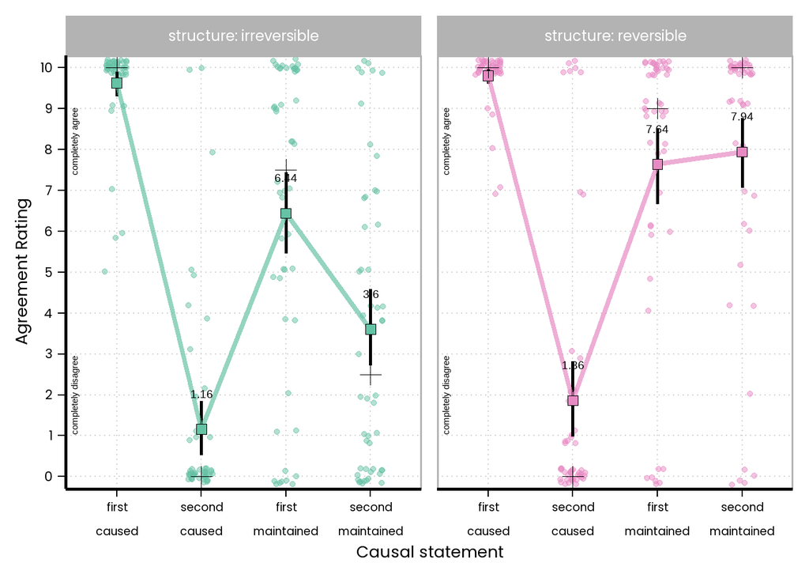

```r
myTheme <- theme(plot.title = element_text(face="bold", size = 22),
        axis.title.x = element_text(size = 20),
        axis.title.y = element_text(size = 20),
        axis.text.x = element_text(size = 14, angle = 0),
        axis.text.y = element_text(size = 16, angle = 0),
        legend.text = element_text(size = 18),
        legend.title = element_text(face = "bold", size = 18),
        strip.text.x = element_text(size = 18),
        panel.grid.major = element_blank(),
        panel.grid.minor = element_blank(),
        panel.background = element_blank(),
        axis.line.x = element_line(colour = "black"),
        axis.line.y = element_line(colour = "black"),
        axis.text = element_text(colour ="black"),
        axis.ticks = element_line(colour ="black"))


tdata_sub <- tdata_long


library(see)
## first, turn sID into a factor
tdata_sub$subj_code <- factor(tdata_sub$subj_code)

pd <- position_dodge(width = 0.3)

tdata_sub$valueJitter <- jitter(tdata_sub$rating, factor = 0.01, amount = 0.004)

theme_set(theme_light(base_size = 20, base_family = "Poppins"))


g <- ggplot(tdata_sub, aes(x = statement, y = valueJitter)) +
  guides(fill=FALSE)+
  facet_grid( ~ structure,labeller = label_both)+
  scale_y_continuous(limits = c(-0.3, 10.3), breaks=seq(0, 10, 1), expand = c(0,0)) +
  geom_jitter(aes(color = structure), alpha = 0.5, width = 0.15, height = 0.2) +
  stat_summary(aes(y = rating, group=1), fun.data = mean_cl_boot,
               geom = "errorbar", width = 0, size = 1) +
  stat_summary(aes(y = rating, group=1, color = structure), fun.y=mean, geom="line",
               shape = 22, size = 1.5, alpha = .7)+
  stat_summary(aes(y = rating, group=1, fill = structure), fun.y=mean, geom="point",
               color = "black", shape = 22, size = 3, group=1, alpha = 1)+
  stat_summary(aes(y = rating,group=1), fun.y=median, geom="point", color = "black", shape = 3, size = 4,
               group=1, alpha = 1, position = position_dodge(width = 0.5))+
  labs(x = "Causal statement", y = "Agreement Rating") +
  scale_color_manual(name = "Strength",values=c("#66c2a5", "#e78ac3", "#8da0cb", "#a6d854"))+
  scale_fill_manual(name = "Strength",values=c("#66c2a5", "#e78ac3", "#8da0cb", "#a6d854"))+
  annotate("text", x = 0.5, y = 2, label = c("completely disagree"), angle = 90)+
  annotate("text", x = 0.5, y = 8.2, label = c("completely agree"), angle = 90)+
  theme(legend.position = "none")+
  myTheme+
  theme(panel.grid.major = element_line(color = "lightgrey",
                                        size = 0.5,
                                        linetype = 'dotted'))+
  stat_summary(aes(label=round(after_stat(y),2)), fun.y=mean, geom="text", size=5,
             vjust = -4)
g
```

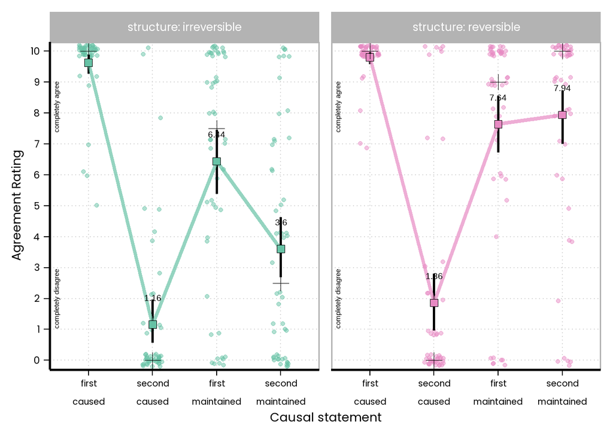

```r
#ggsave("results_means_mainDV.svg",width=12,height=5)
#ggsave("results_means_mainDV.pdf",width=12,height=5)

g
```

```r
library(ggridges)
```

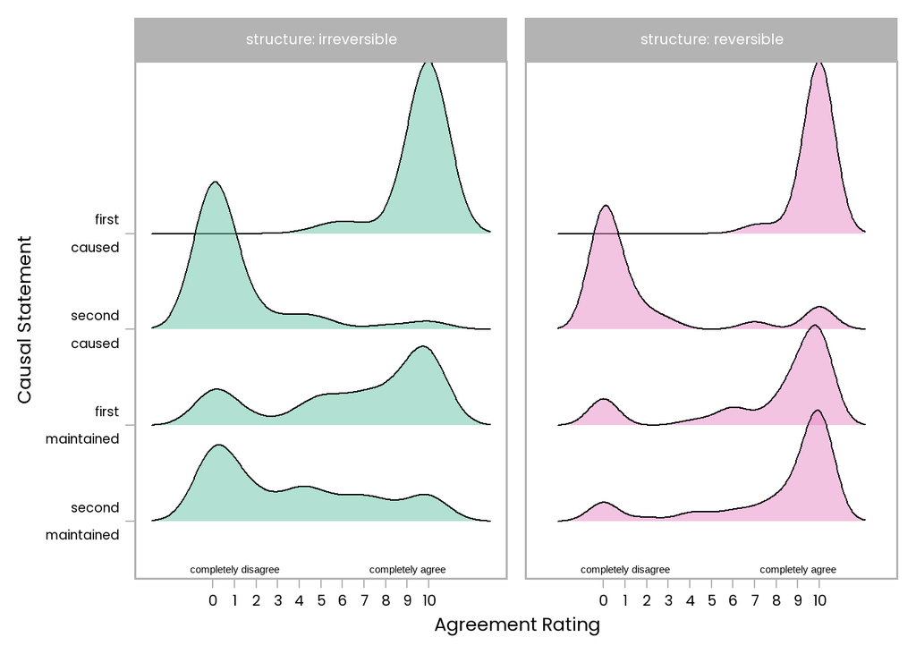

```r
g2 <- ggplot(tdata_long, aes(x = rating, y = statement, fill = structure)) +
  facet_grid( ~ structure,labeller = label_both)+
  scale_x_continuous(breaks = seq(0, 10, 1))+
  geom_density_ridges(alpha = 0.5)+
  scale_fill_manual(values=c("#66c2a5", "#e78ac3", "#8da0cb", "#a6d854"))+
  labs(x = "Agreement Rating", y = "Causal Statement") +
  scale_y_discrete(limits=rev)+
  myTheme+
  theme_light(base_family = "Poppins", base_size = 20)+
  theme(panel.grid = element_blank(), axis.text = element_text(colour ="black"))+
  theme(legend.position="none",
        legend.title=element_blank(),legend.key.width = unit(1.95, 'cm'))+
  theme(axis.text.y = element_text(size = 14, angle = 0))+
  annotate("text", y = 0.5, x = 1, label = c("completely disagree"), angle = 0)+
  annotate("text", y = 0.5, x = 9, label = c("completely agree"), angle = 0)

g2
```

```r
#ggsave("results_dist.svg",width=12,height=5)
#ggsave("results_dist.pdf",width=12,height=5)
```

# 4 Analyses

## 4.1 Mixed ANOVA

```r
library(afex)
library(emmeans)

a1 <- aov_car(rating ~ structure*statement + Error(subj_code/statement), tdata_long, anova_table = list(es = "pes"))
```

```
## Contrasts set to contr.sum for the following variables: structure
```

```r
a1
```

```
## Anova Table (Type 3 tests)
##
## Response: rating
##                Effect           df  MSE          F  pes p.value
## 1           structure        1, 98 9.68  26.61 *** .214   <.001
## 2           statement 2.67, 261.70 9.23 142.29 *** .592   <.001
## 3 structure:statement 2.67, 261.70 9.23  10.65 *** .098   <.001
## ---
## Signif. codes:  0 '***' 0.001 '**' 0.01 '*' 0.05 '+' 0.1 ' ' 1
##
## Sphericity correction method: GG
```

Predicted interaction effect is significant, but other main effects should also be visualized.

Visualize Main effect of structure (causal reversibility):

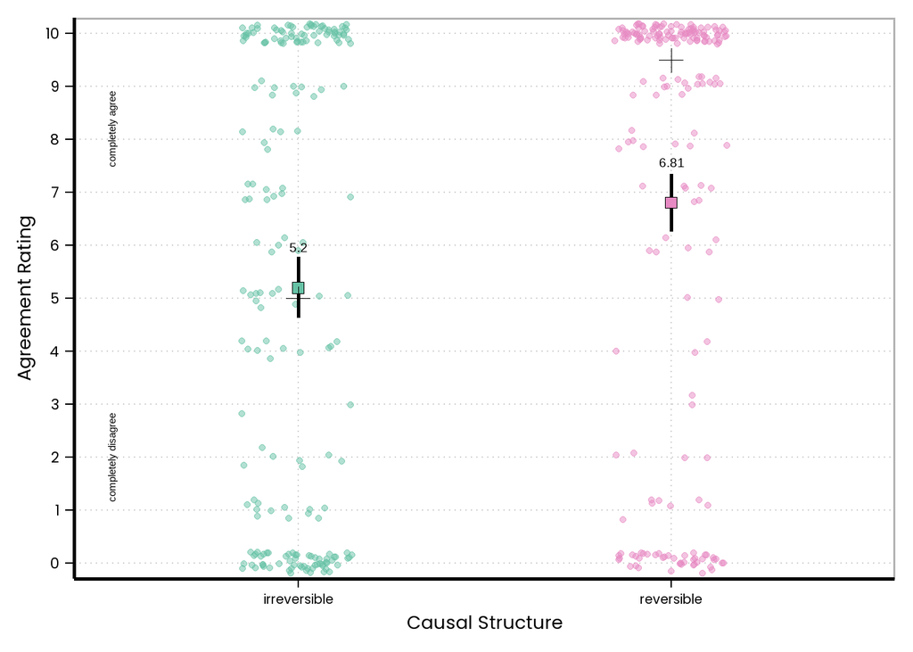

```r
tdata_sub <- tdata_long


library(see)
## first, turn sID into a factor
tdata_sub$subj_code <- factor(tdata_sub$subj_code)

pd <- position_dodge(width = 0.3)

tdata_sub$valueJitter <- jitter(tdata_sub$rating, factor = 0.01, amount = 0.004)

theme_set(theme_light(base_size = 20, base_family = "Poppins"))


g <- ggplot(tdata_sub, aes(x = structure, y = valueJitter)) +
  guides(fill=FALSE)+
  scale_y_continuous(limits = c(-0.3, 10.3), breaks=seq(0, 10, 1), expand = c(0,0)) +
  geom_jitter(aes(color = structure), alpha = 0.5, width = 0.15, height = 0.2) +
  stat_summary(aes(y = rating, group=1), fun.data = mean_cl_boot,
               geom = "errorbar", width = 0, size = 1) +
  stat_summary(aes(y = rating, group=1, fill = structure), fun.y=mean, geom="point",
               color = "black", shape = 22, size = 3, group=1, alpha = 1)+
  stat_summary(aes(y = rating,group=1), fun.y=median, geom="point", color = "black", shape = 3, size = 4,
               group=1, alpha = 1, position = position_dodge(width = 0.5))+
  labs(x = "Causal Structure", y = "Agreement Rating") +
  scale_color_manual(name = "Strength",values=c("#66c2a5", "#e78ac3", "#8da0cb", "#a6d854"))+
  scale_fill_manual(name = "Strength",values=c("#66c2a5", "#e78ac3", "#8da0cb", "#a6d854"))+
  annotate("text", x = 0.5, y = 2, label = c("completely disagree"), angle = 90)+
  annotate("text", x = 0.5, y = 8.2, label = c("completely agree"), angle = 90)+
  theme(legend.position = "none")+
  myTheme+
  theme(panel.grid.major = element_line(color = "lightgrey",
                                        size = 0.5,
                                        linetype = 'dotted'))+
  stat_summary(aes(label=round(after_stat(y),2)), fun.y=mean, geom="text", size=5,
             vjust = -4)

g
```

Main effect of statement:

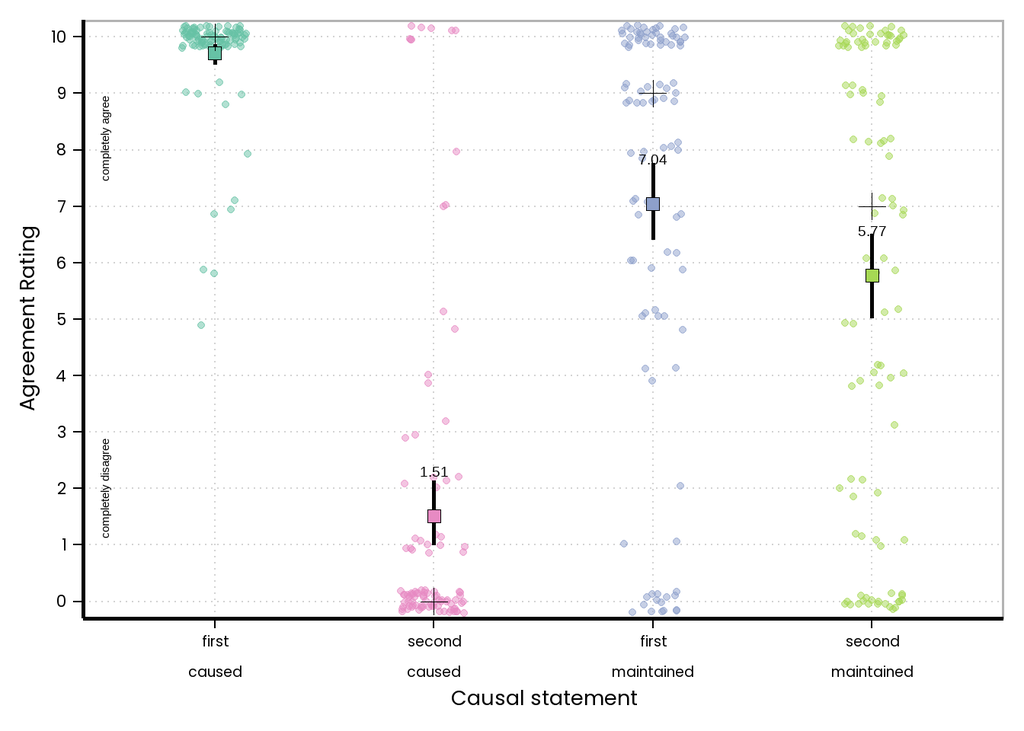

```r
tdata_sub <- tdata_long


library(see)
## first, turn sID into a factor
tdata_sub$subj_code <- factor(tdata_sub$subj_code)

pd <- position_dodge(width = 0.3)

tdata_sub$valueJitter <- jitter(tdata_sub$rating, factor = 0.01, amount = 0.004)

theme_set(theme_light(base_size = 20, base_family = "Poppins"))


g <- ggplot(tdata_sub, aes(x = statement, y = valueJitter)) +
  guides(fill=FALSE)+
  scale_y_continuous(limits = c(-0.3, 10.3), breaks=seq(0, 10, 1), expand = c(0,0)) +
  geom_jitter(aes(color = statement), alpha = 0.5, width = 0.15, height = 0.2) +
  stat_summary(aes(y = rating, group=1), fun.data = mean_cl_boot,
               geom = "errorbar", width = 0, size = 1) +
  #stat_summary(aes(y = rating, group=1, color = structure), fun.y=mean, geom="line",
   #            shape = 22, size = 1.5, alpha = .7)+
  stat_summary(aes(y = rating, group=1, fill = statement), fun.y=mean, geom="point",
               color = "black", shape = 22, size = 3, group=1, alpha = 1)+
  stat_summary(aes(y = rating,group=1), fun.y=median, geom="point", color = "black", shape = 3, size = 4,
               group=1, alpha = 1, position = position_dodge(width = 0.5))+
  labs(x = "Causal statement", y = "Agreement Rating") +
  scale_color_manual(name = "Strength",values=c("#66c2a5", "#e78ac3", "#8da0cb", "#a6d854"))+
  scale_fill_manual(name = "Strength",values=c("#66c2a5", "#e78ac3", "#8da0cb", "#a6d854"))+
  annotate("text", x = 0.5, y = 2, label = c("completely disagree"), angle = 90)+
  annotate("text", x = 0.5, y = 8.2, label = c("completely agree"), angle = 90)+
  theme(legend.position = "none")+
  myTheme+
  theme(panel.grid.major = element_line(color = "lightgrey",
                                        size = 0.5,
                                        linetype = 'dotted'))+
  stat_summary(aes(label=round(after_stat(y),2)), fun.y=mean, geom="text", size=5,
             vjust = -4)

g
```

## 4.2 Contrasts

```r
library(lsmeans)
# means

ls2 <- lsmeans(a1, c("structure", "statement"))
ls2
```

```
##  structure    statement          lsmean    SE df lower.CL upper.CL
##  irreversible first..caused        9.62 0.131 98    9.361     9.88
##  reversible   first..caused        9.80 0.131 98    9.541    10.06
##  irreversible second..caused       1.16 0.420 98    0.327     1.99
##  reversible   second..caused       1.86 0.420 98    1.027     2.69
##  irreversible first..maintained    6.44 0.508 98    5.431     7.45
##  reversible   first..maintained    7.64 0.508 98    6.631     8.65
##  irreversible second..maintained   3.60 0.485 98    2.638     4.56
##  reversible   second..maintained   7.94 0.485 98    6.978     8.90
##
## Confidence level used: 0.95
```

```r
contrasts <- emmeans(a1, ~ statement|structure)
s <- pairs(contrasts, adjust = "none")


s
```

```
## structure = irreversible:
##  contrast                               estimate    SE df t.ratio p.value
##  first..caused - second..caused             8.46 0.471 98  17.960  <.0001
##  first..caused - first..maintained          3.18 0.513 98   6.202  <.0001
##  first..caused - second..maintained         6.02 0.511 98  11.774  <.0001
##  second..caused - first..maintained        -5.28 0.630 98  -8.386  <.0001
##  second..caused - second..maintained       -2.44 0.645 98  -3.785  0.0003
##  first..maintained - second..maintained     2.84 0.643 98   4.420  <.0001
##
## structure = reversible:
##  contrast                               estimate    SE df t.ratio p.value
##  first..caused - second..caused             7.94 0.471 98  16.856  <.0001
##  first..caused - first..maintained          2.16 0.513 98   4.213  0.0001
##  first..caused - second..maintained         1.86 0.511 98   3.638  0.0004
##  second..caused - first..maintained        -5.78 0.630 98  -9.180  <.0001
##  second..caused - second..maintained       -6.08 0.645 98  -9.432  <.0001
##  first..maintained - second..maintained    -0.30 0.643 98  -0.467  0.6416
```

```r
confint(s, level = 0.95)
```

```
## structure = irreversible:
##  contrast                               estimate    SE df lower.CL upper.CL
##  first..caused - second..caused             8.46 0.471 98    7.525    9.395
##  first..caused - first..maintained          3.18 0.513 98    2.163    4.197
##  first..caused - second..maintained         6.02 0.511 98    5.005    7.035
##  second..caused - first..maintained        -5.28 0.630 98   -6.530   -4.030
##  second..caused - second..maintained       -2.44 0.645 98   -3.719   -1.161
##  first..maintained - second..maintained     2.84 0.643 98    1.565    4.115
##
## structure = reversible:
##  contrast                               estimate    SE df lower.CL upper.CL
##  first..caused - second..caused             7.94 0.471 98    7.005    8.875
##  first..caused - first..maintained          2.16 0.513 98    1.143    3.177
##  first..caused - second..maintained         1.86 0.511 98    0.845    2.875
##  second..caused - first..maintained        -5.78 0.630 98   -7.030   -4.530
##  second..caused - second..maintained       -6.08 0.645 98   -7.359   -4.801
##  first..maintained - second..maintained    -0.30 0.643 98   -1.575    0.975
##
## Confidence level used: 0.95
```

Planned contrasts in the list above are “first caused - second caused” in each reversibility condition. Both are significant.

Get effect standardized effect sizes for the contrasts

First get the SDs that need to be pooled (and also the correlations between measures for the within-comparisons)

```r
library(dplyr)

tdata_long %>%
  group_by(structure, statement) %>%
  summarise_at(vars(rating), list(name=sd))
```

```
## # A tibble: 8 × 3
## # Groups:   structure [2]
##   structure    statement              name
##   <fct>        <fct>                 <dbl>
## 1 irreversible "first \ncaused"      1.12
## 2 irreversible "second \ncaused"     2.48
## 3 irreversible "first \nmaintained"  3.74
## 4 irreversible "second \nmaintained" 3.59
## 5 reversible   "first \ncaused"      0.670
## 6 reversible   "second \ncaused"     3.39
## 7 reversible   "first \nmaintained"  3.44
## 8 reversible   "second \nmaintained" 3.26
```

```r
library(dplyr)

tdata %>%
  group_by(structure) %>%
  summarize(cor=cor(first_caused_rating, second_caused_rating))
```

```
## # A tibble: 2 × 2
##   structure       cor
##   <fct>         <dbl>
## 1 irreversible -0.337
## 2 reversible   -0.219
```

```r
# using the functions from the MOTE package (see https://matthewbjane.quarto.pub/guide-to-effect-sizes-and-confidence-intervals/Standardized-Mean-Differences.html#sec-repeated-measures-drm)

library(MOTE)
# irreversible condition

#structure    statement          lsmean    SE df lower.CL upper.CL
# irreversible first..caused        9.62 0.131 98    9.361     9.88
# irreversible second..caused       1.16 0.420 98    0.327     1.99



stats <- d.dep.t.rm(
  m1 = 9.62,
  m2 = 1.16,
  sd1 = 1.1228608,
  sd2 = 2.4773257,
  n = 50,
  a = 0.05,
  r = -0.3371902
)

stats$estimate
```

```
## [1] "$d_{rm}$ = 4.54, 95\\% CI [3.60, 5.46]"
```

```r
# reversible condition

#structure    statement          lsmean    SE df lower.CL upper.CL
# reversible   first..caused        9.80 0.131 98    9.541    10.06
# reversible   second..caused       1.86 0.420 98    1.027     2.69



stats <- d.dep.t.rm(
  m1 = 9.80,
  m2 = 1.86,
  sd1 = 0.6700594,
  sd2 = 3.3867087,
  n = 50,
  a = 0.05,
  r = -0.2194333
)

stats$estimate
```

```
## [1] "$d_{rm}$ = 3.45, 95\\% CI [2.71, 4.18]"
```

Now contrast testing the maintainer ratings in each reversibility condition. The code below will produce a long list from which the correct contrast must be looked up.

```r
contrasts <- emmeans(a1, ~ statement*structure)
s <- pairs(contrasts, adjust = "none")


s
```

```
##  contrast                                                         estimate
##  first..caused irreversible - second..caused irreversible             8.46
##  first..caused irreversible - first..maintained irreversible          3.18
##  first..caused irreversible - second..maintained irreversible         6.02
##  first..caused irreversible - first..caused reversible               -0.18
##  first..caused irreversible - second..caused reversible               7.76
##  first..caused irreversible - first..maintained reversible            1.98
##  first..caused irreversible - second..maintained reversible           1.68
##  second..caused irreversible - first..maintained irreversible        -5.28
##  second..caused irreversible - second..maintained irreversible       -2.44
##  second..caused irreversible - first..caused reversible              -8.64
##  second..caused irreversible - second..caused reversible             -0.70
##  second..caused irreversible - first..maintained reversible          -6.48
##  second..caused irreversible - second..maintained reversible         -6.78
##  first..maintained irreversible - second..maintained irreversible     2.84
##  first..maintained irreversible - first..caused reversible           -3.36
##  first..maintained irreversible - second..caused reversible           4.58
##  first..maintained irreversible - first..maintained reversible       -1.20
##  first..maintained irreversible - second..maintained reversible      -1.50
##  second..maintained irreversible - first..caused reversible          -6.20
##  second..maintained irreversible - second..caused reversible          1.74
##  second..maintained irreversible - first..maintained reversible      -4.04
##  second..maintained irreversible - second..maintained reversible     -4.34
##  first..caused reversible - second..caused reversible                 7.94
##  first..caused reversible - first..maintained reversible              2.16
##  first..caused reversible - second..maintained reversible             1.86
##  second..caused reversible - first..maintained reversible            -5.78
##  second..caused reversible - second..maintained reversible           -6.08
##  first..maintained reversible - second..maintained reversible        -0.30
##     SE df t.ratio p.value
##  0.471 98  17.960  <.0001
##  0.513 98   6.202  <.0001
##  0.511 98  11.774  <.0001
##  0.185 98  -0.973  0.3328
##  0.440 98  17.656  <.0001
##  0.525 98   3.773  0.0003
##  0.502 98   3.347  0.0012
##  0.630 98  -8.386  <.0001
##  0.645 98  -3.785  0.0003
##  0.440 98 -19.658  <.0001
##  0.593 98  -1.180  0.2410
##  0.659 98  -9.832  <.0001
##  0.641 98 -10.577  <.0001
##  0.643 98   4.420  <.0001
##  0.525 98  -6.402  <.0001
##  0.659 98   6.949  <.0001
##  0.719 98  -1.669  0.0982
##  0.702 98  -2.136  0.0352
##  0.502 98 -12.352  <.0001
##  0.641 98   2.714  0.0078
##  0.702 98  -5.753  <.0001
##  0.685 98  -6.332  <.0001
##  0.471 98  16.856  <.0001
##  0.513 98   4.213  0.0001
##  0.511 98   3.638  0.0004
##  0.630 98  -9.180  <.0001
##  0.645 98  -9.432  <.0001
##  0.643 98  -0.467  0.6416
```

```r
confint(s, level = 0.95)
```

```
##  contrast                                                         estimate
##  first..caused irreversible - second..caused irreversible             8.46
##  first..caused irreversible - first..maintained irreversible          3.18
##  first..caused irreversible - second..maintained irreversible         6.02
##  first..caused irreversible - first..caused reversible               -0.18
##  first..caused irreversible - second..caused reversible               7.76
##  first..caused irreversible - first..maintained reversible            1.98
##  first..caused irreversible - second..maintained reversible           1.68
##  second..caused irreversible - first..maintained irreversible        -5.28
##  second..caused irreversible - second..maintained irreversible       -2.44
##  second..caused irreversible - first..caused reversible              -8.64
##  second..caused irreversible - second..caused reversible             -0.70
##  second..caused irreversible - first..maintained reversible          -6.48
##  second..caused irreversible - second..maintained reversible         -6.78
##  first..maintained irreversible - second..maintained irreversible     2.84
##  first..maintained irreversible - first..caused reversible           -3.36
##  first..maintained irreversible - second..caused reversible           4.58
##  first..maintained irreversible - first..maintained reversible       -1.20
##  first..maintained irreversible - second..maintained reversible      -1.50
##  second..maintained irreversible - first..caused reversible          -6.20
##  second..maintained irreversible - second..caused reversible          1.74
##  second..maintained irreversible - first..maintained reversible      -4.04
##  second..maintained irreversible - second..maintained reversible     -4.34
##  first..caused reversible - second..caused reversible                 7.94
##  first..caused reversible - first..maintained reversible              2.16
##  first..caused reversible - second..maintained reversible             1.86
##  second..caused reversible - first..maintained reversible            -5.78
##  second..caused reversible - second..maintained reversible           -6.08
##  first..maintained reversible - second..maintained reversible        -0.30
##     SE df lower.CL upper.CL
##  0.471 98    7.525    9.395
##  0.513 98    2.163    4.197
##  0.511 98    5.005    7.035
##  0.185 98   -0.547    0.187
##  0.440 98    6.888    8.632
##  0.525 98    0.939    3.021
##  0.502 98    0.684    2.676
##  0.630 98   -6.530   -4.030
##  0.645 98   -3.719   -1.161
##  0.440 98   -9.512   -7.768
##  0.593 98   -1.878    0.478
##  0.659 98   -7.788   -5.172
##  0.641 98   -8.052   -5.508
##  0.643 98    1.565    4.115
##  0.525 98   -4.401   -2.319
##  0.659 98    3.272    5.888
##  0.719 98   -2.626    0.226
##  0.702 98   -2.894   -0.106
##  0.502 98   -7.196   -5.204
##  0.641 98    0.468    3.012
##  0.702 98   -5.434   -2.646
##  0.685 98   -5.700   -2.980
##  0.471 98    7.005    8.875
##  0.513 98    1.143    3.177
##  0.511 98    0.845    2.875
##  0.630 98   -7.030   -4.530
##  0.645 98   -7.359   -4.801
##  0.643 98   -1.575    0.975
##
## Confidence level used: 0.95
```

The planned contrast from this list is the one comparing the maintainer ratings between the reversibility conditions: “second..maintained irreversible - second..maintained reversible”, which is significant.

Get effect size

```r
#structure    statement          lsmean    SE df lower.CL upper.CL
#reversible   second..maintained   7.94 0.485 98    6.978     8.90
#irreversible second..maintained   3.60 0.485 98    2.638     4.56

#SDs
#reversible second \nmaintained 3.2602116
#irreversible   second \nmaintained 3.5856858

stats <- d.ind.t(
  m1 = 7.94,
  m2 = 3.60,
  sd1 = 3.2602116,
  sd2 = 3.5856858,
  n1 = 50,
  n2 = 50,
  a = 0.05
)

stats$estimate
```

```
## [1] "$d_s$ = 1.27, 95\\% CI [0.83, 1.69]"
```